# **Detecção de fraude de cartão de crédito** 🔍 💳

Amanda Caroline de Oliveira Pires - 12559090

Pedro Luis - 12558144

Rafael Batista Pereira - 12610462

Universidade de São Paulo, São Carlos, Brasil.

# **Sumário**

- Introdução
- Análise exploratória e descritiva
  - Correlação
- Balanceamento dos dados
  - Undersampling
  - Oversampling (SMOTE)
- Modelos
  - Classificador Logístico
  - Classificador Random Forest
- Métricas de Avaliação
- Matriz de Confusão
- Acurácia
- Precisão
- F1-Score
- Recall
- Conclusão

## **Introdução**

O presente projeto tem como objetivo classificar transações de cartão de crédito anônimas como fraudulentas ou genuínas. Como estamos trabalhando com dados desbalanceados, empregaremos métodos capazes de realizar observações precisas e assim manter o equilíbrio.

O dataset contém apenas variáveis de entrada numéricas que são o resultado de uma transformação PCA. Por questões de confidencialidade, não foi fornecido os recursos originais e mais informações básicas sobre os dados. As variáveis V1, V2, … V28 são os componentes principais obtidos com PCA, as únicas características que não foram transformadas com PCA são 'Time' e 'Amount'.

Dataset: https://www.kaggle.com/datasets/mlg-ulb/creditcardfraud

## **Bibliotecas e Funções**

```python
#!pip  install -U imbalanced-learn
#!pip install lazypredict
```

```python
import pandas as pd
import numpy as np
import matplotlib.pyplot as plt
import seaborn as sns
sns.set_theme(style="whitegrid", palette="pastel")
from sklearn.preprocessing import StandardScaler
from sklearn.model_selection import train_test_split, cross_validate, cross_val_score
from imblearn.under_sampling import RandomUnderSampler
from imblearn.over_sampling import SMOTE
from sklearn.linear_model import LogisticRegression
from sklearn.ensemble import RandomForestClassifier
from lazypredict.Supervised import LazyClassifier
from sklearn.utils import shuffle
from sklearn.metrics import confusion_matrix, accuracy_score, f1_score, precision_score, recall_score, roc_curve, roc_auc_score
import sklearn.metrics as metrics
from sklearn.metrics import accuracy_score, confusion_matrix, classification_report
from sklearn.model_selection import GridSearchCV
```

## **Leitura dos Dados**

```python
data_backup = pd.read_csv('C:/Users/amand/OneDrive/Área de Trabalho/Projeto ICD/creditcard.csv', header = 0)
#data_backup = pd.read_csv('/content/drive/MyDrive/Semestres/4º Semestre/ICD/Projeto/creditcard.csv', header = 0)
```

## **Preservando os dados originais**

```python
data = data_backup.copy()
```

## **Análise exploratória e descritiva**

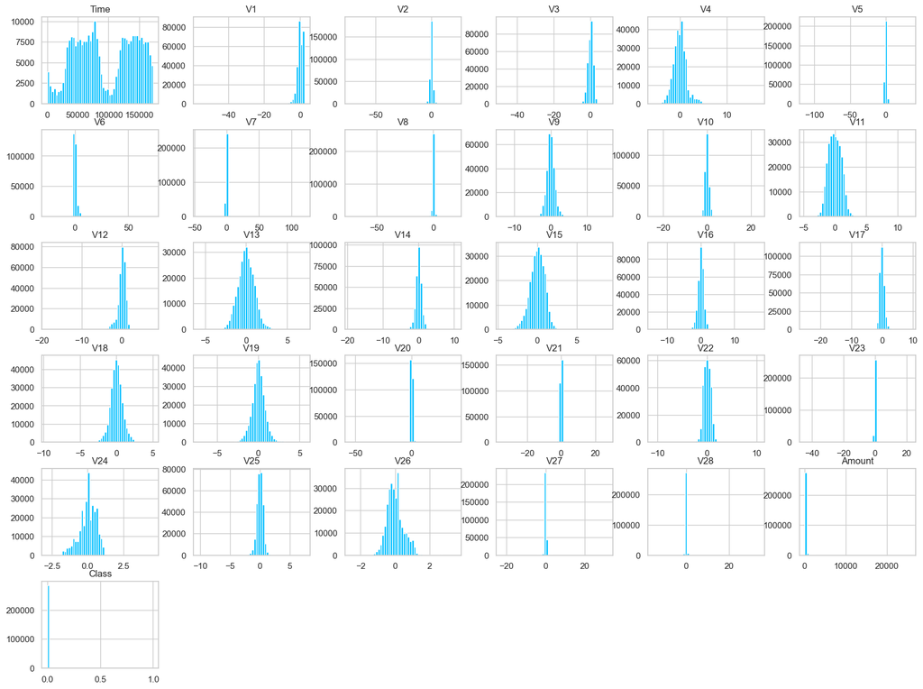

```python
data.hist(bins=50, figsize=(20,15), color = 'deepskyblue')

plt.show()
```

```python
# Estatisticas descritivas
data.describe()
```

|  | Time | V1 | V2 | V3 | V4 | V5 | V6 | V7 | V8 | V9 | ... | V21 | V22 | V23 | V24 | V25 | V26 | V27 | V28 | Amount | Class |
| --- | --- | --- | --- | --- | --- | --- | --- | --- | --- | --- | --- | --- | --- | --- | --- | --- | --- | --- | --- | --- | --- |
| count | 284807.00 | 284807.00 | 284807.00 | 284807.00 | 284807.00 | 284807.00 | 284807.00 | 284807.00 | 284807.00 | 284807.00 | ... | 284807.00 | 284807.00 | 284807.00 | 284807.00 | 284807.00 | 284807.00 | 284807.00 | 284807.00 | 284807.00 | 284807.00 |
| mean | 94813.86 | 0.00 | 0.00 | -0.00 | 0.00 | 0.00 | 0.00 | -0.00 | 0.00 | -0.00 | ... | 0.00 | -0.00 | 0.00 | 0.00 | 0.00 | 0.00 | -0.00 | -0.00 | 88.35 | 0.00 |
| std | 47488.15 | 1.96 | 1.65 | 1.52 | 1.42 | 1.38 | 1.33 | 1.24 | 1.19 | 1.10 | ... | 0.73 | 0.73 | 0.62 | 0.61 | 0.52 | 0.48 | 0.40 | 0.33 | 250.12 | 0.04 |
| min | 0.00 | -56.41 | -72.72 | -48.33 | -5.68 | -113.74 | -26.16 | -43.56 | -73.22 | -13.43 | ... | -34.83 | -10.93 | -44.81 | -2.84 | -10.30 | -2.60 | -22.57 | -15.43 | 0.00 | 0.00 |
| 25% | 54201.50 | -0.92 | -0.60 | -0.89 | -0.85 | -0.69 | -0.77 | -0.55 | -0.21 | -0.64 | ... | -0.23 | -0.54 | -0.16 | -0.35 | -0.32 | -0.33 | -0.07 | -0.05 | 5.60 | 0.00 |
| 50% | 84692.00 | 0.02 | 0.07 | 0.18 | -0.02 | -0.05 | -0.27 | 0.04 | 0.02 | -0.05 | ... | -0.03 | 0.01 | -0.01 | 0.04 | 0.02 | -0.05 | 0.00 | 0.01 | 22.00 | 0.00 |
| 75% | 139320.50 | 1.32 | 0.80 | 1.03 | 0.74 | 0.61 | 0.40 | 0.57 | 0.33 | 0.60 | ... | 0.19 | 0.53 | 0.15 | 0.44 | 0.35 | 0.24 | 0.09 | 0.08 | 77.16 | 0.00 |
| max | 172792.00 | 2.45 | 22.06 | 9.38 | 16.88 | 34.80 | 73.30 | 120.59 | 20.01 | 15.59 | ... | 27.20 | 10.50 | 22.53 | 4.58 | 7.52 | 3.52 | 31.61 | 33.85 | 25691.16 | 1.00 |

8 rows × 31 columns

```python
# Verificando o número de valores únicos
data.nunique()
```

```
Time      124592
V1        275663
V2        275663
V3        275663
V4        275663
V5        275663
V6        275663
V7        275663
V8        275663
V9        275663
V10       275663
V11       275663
V12       275663
V13       275663
V14       275663
V15       275663
V16       275663
V17       275663
V18       275663
V19       275663
V20       275663
V21       275663
V22       275663
V23       275663
V24       275663
V25       275663
V26       275663
V27       275663
V28       275663
Amount     32767
Class          2
dtype: int64
```

```python
# Separando em X  e y
X = data.drop('Class', axis=1)
y = data.Class
```

```python
# Numero de fraudes e transacoes geninuinas
y.value_counts()
```

```
0    284315
1       492
Name: Class, dtype: int64
```

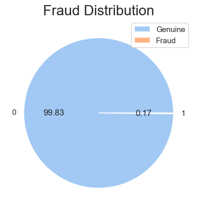

```python
# Visualiza a proporção desses dados
y.value_counts().plot.pie(autopct='%.2f');
plt.legend(labels=['Genuine','Fraud'])
plt.title('Fraud Distribution', size = 20)
plt.axis('off')
plt.show()
```

```python
# Verificando proporção de transações fraudulentas

y.value_counts()/y.shape[0]*100
```

```
0   99.83
1    0.17
Name: Class, dtype: float64
```

Ou seja, 99.83 **não** são fraudes e 0.17 são

```python
# Resumo estatístico
fraude = data[data['Class'] == 1]
normal = data[data['Class'] == 0]

print("Fraude - Resumo estatístico para a variável Amount")
print(fraude["Amount"].describe())
print("\nNão Fraude - Resumo estatístico para a variável Amount")
print(normal["Amount"].describe())
```

```
Fraude - Resumo estatístico para a variável Amount
count    492.00
mean     122.21
std      256.68
min        0.00
25%        1.00
50%        9.25
75%      105.89
max     2125.87
Name: Amount, dtype: float64

Não Fraude - Resumo estatístico para a variável Amount
count   284315.00
mean        88.29
std        250.11
min          0.00
25%          5.65
50%         22.00
75%         77.05
max      25691.16
Name: Amount, dtype: float64
```

Avaliando se existe relação entre os gastos e sua distribuiçao temporal

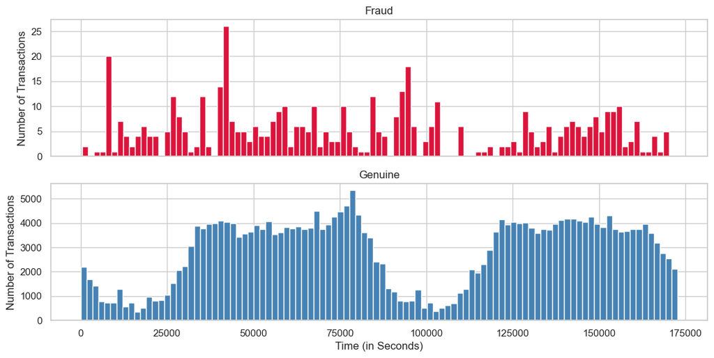

```python
# visualização do numero de transacoes fraudulentas e genuínas ao longo do tempo
f, (ax1, ax2) = plt.subplots(2, 1, sharex=True, figsize=(13,6))

bins = 100

ax1.hist(data.Time[data.Class == 1], bins = bins, color='crimson')
ax1.set_title('Fraud')
ax1.set_ylabel('Number of Transactions')

ax2.hist(data.Time[data.Class == 0], bins = bins, color='steelblue')
ax2.set_title('Genuine')
ax2.set_ylabel('Number of Transactions')

plt.xlabel('Time (in Seconds)')
plt.show()
```

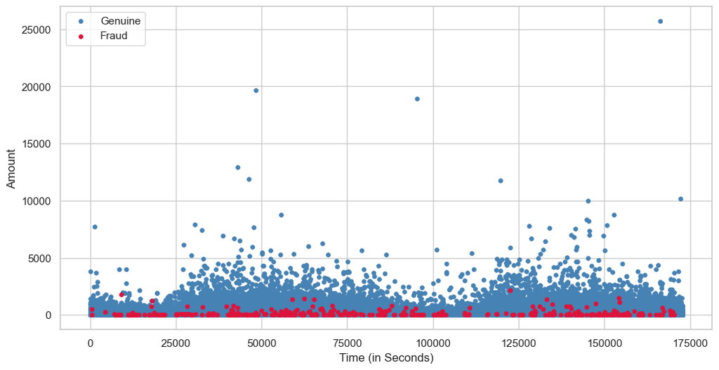

```python
# visualizacao da relacao entre valores de transacoes ao longo do tempo
f, ax = plt.subplots(1, 1, sharex=True, figsize=(12,6))

ax.scatter(data.Time[data.Class == 0], data.Amount[data.Class == 0], s=15, color='steelblue', label = "Genuine")
ax.scatter(data.Time[data.Class == 1], data.Amount[data.Class == 1], s=15, color='crimson', label = "Fraud")

plt.xlabel('Time (in Seconds)')
plt.ylabel('Amount')
plt.legend()
plt.show()
```

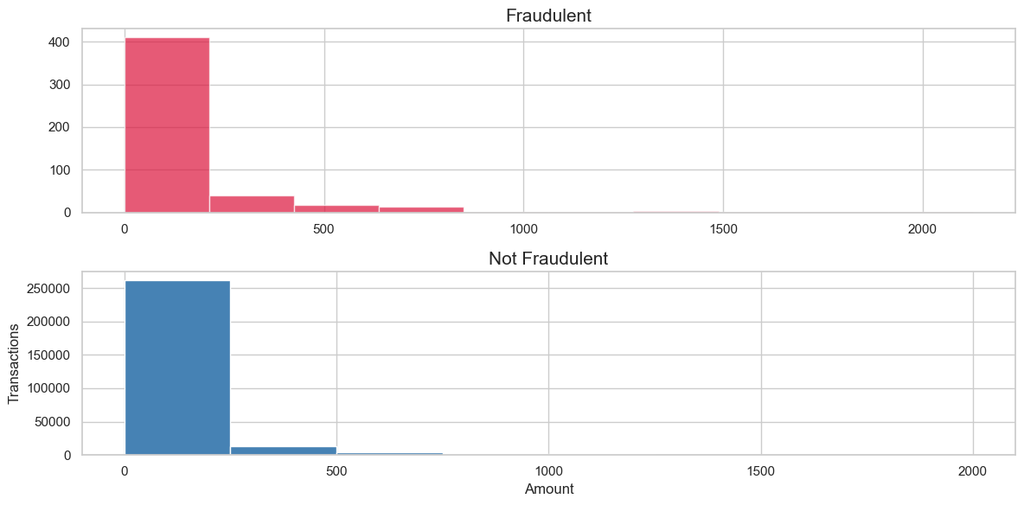

```python
# histograma
fig, (ax1, ax2) = plt.subplots(nrows=2, ncols=1, figsize=(12,6))

ax2.hist(data[data['Class'] == 0]['Amount'], bins=[0,250,500,750,1000,1250,1500,1750,2000], color='steelblue');
ax2.set_xticks(ticks=[0,500,1000,1500,2000])
ax2.set_title("Not Fraudulent", fontsize=15);


ax1.hist(data[data['Class'] == 1]['Amount'], alpha = 0.7, color='crimson');
ax1.set_title("Fraudulent", fontsize=15);

plt.xlabel('Amount')
plt.ylabel('Transactions')
plt.tight_layout()
```

## **Correlações**

Verificando a correlação entre as variáveis a fim de evitar a multicolinearidade (problema no qual induz o modelo ao erro).

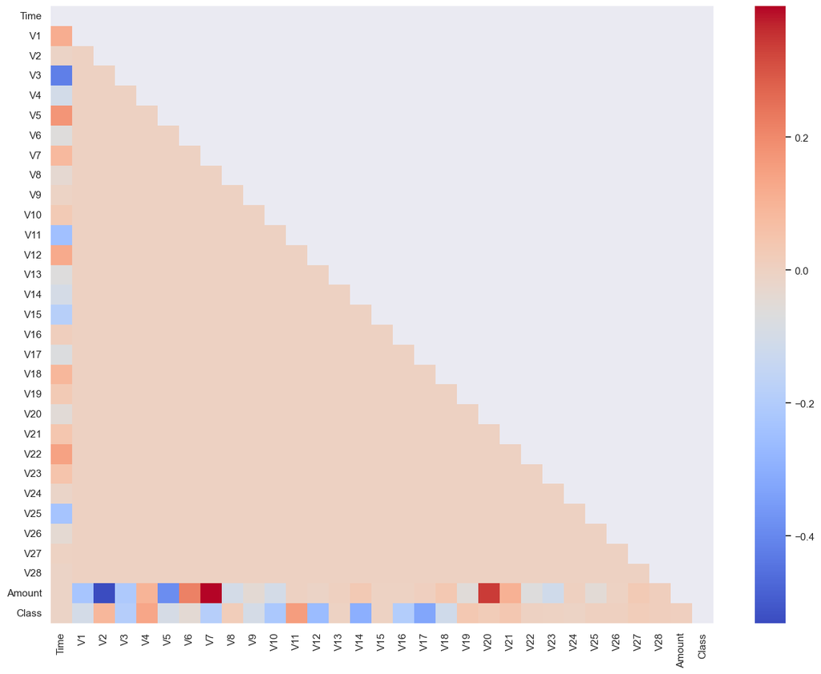

```python
corr = data.corr()
sns.set(rc={'figure.figsize':(16,12)})
mask = np.zeros_like(corr, dtype=np.bool)
mask[np.triu_indices_from(mask)] = True
sns.heatmap(corr, cmap='coolwarm', mask=mask)
plt.show()
```

Maiores correlações entre:

- Amount e V2 (-0.53)
- Time e V3 (-0.42)
- Amount e V7 (0.40)

Interpretando uma correlação alta como se as duas variáveis entregassem a mesma informação. Esperamos que a variável Amount possa ser explicada por V2 e V7 devido correlação considerável entre essas e Amount. Outras variáveis com correlações consideráveis são Time e V3, não iremos inserir a váriavel Time para construção dos modelos porém V3 e as demais serão.

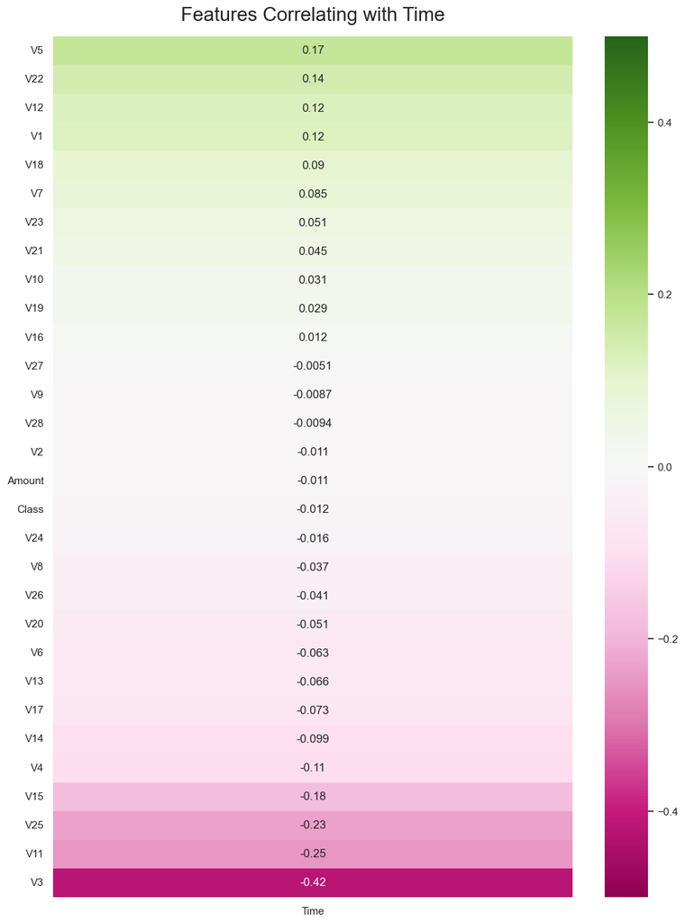

```python
plt.figure(figsize=(12, 16))
heatmap = sns.heatmap(data.corr()[['Time']].sort_values(by='Time', ascending=False).drop('Time'), vmin=-0.5, vmax=0.5, annot=True, cmap="PiYG")
heatmap.set_title('Features Correlating with Time', fontdict={'fontsize':20}, pad=16);
```

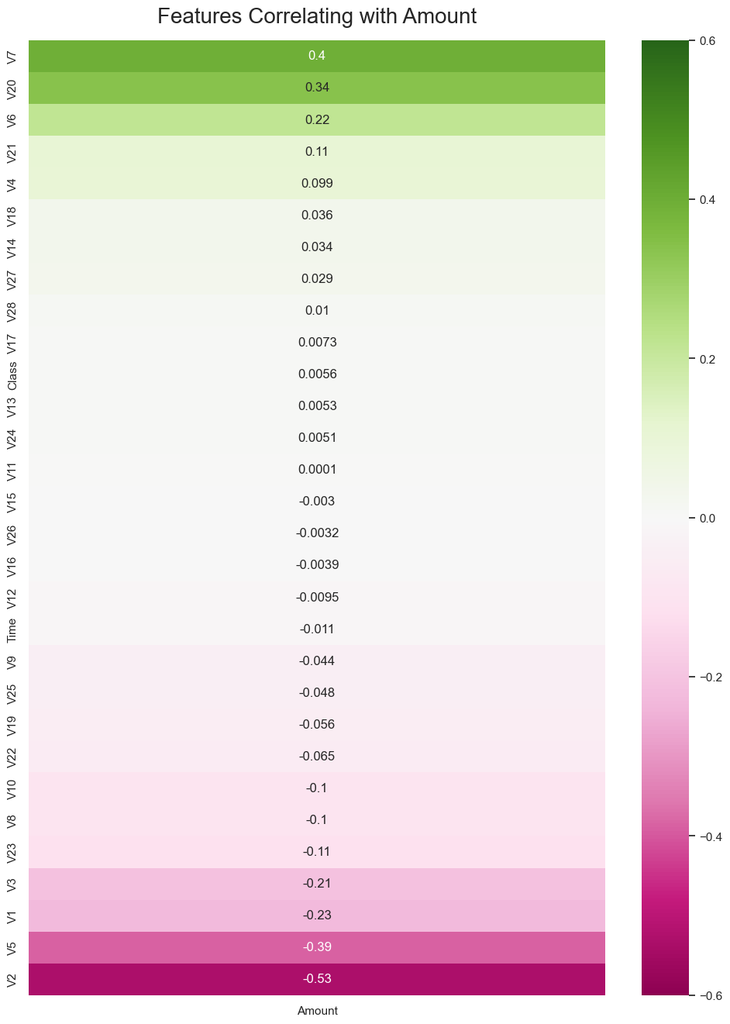

```python
plt.figure(figsize=(12, 16))
heatmap = sns.heatmap(data.corr()[['Amount']].sort_values(by='Amount', ascending=False).drop('Amount'), vmin=-0.6, vmax=0.6, annot=True, cmap="PiYG")
heatmap.set_title('Features Correlating with Amount', fontdict={'fontsize':20}, pad=16);
```

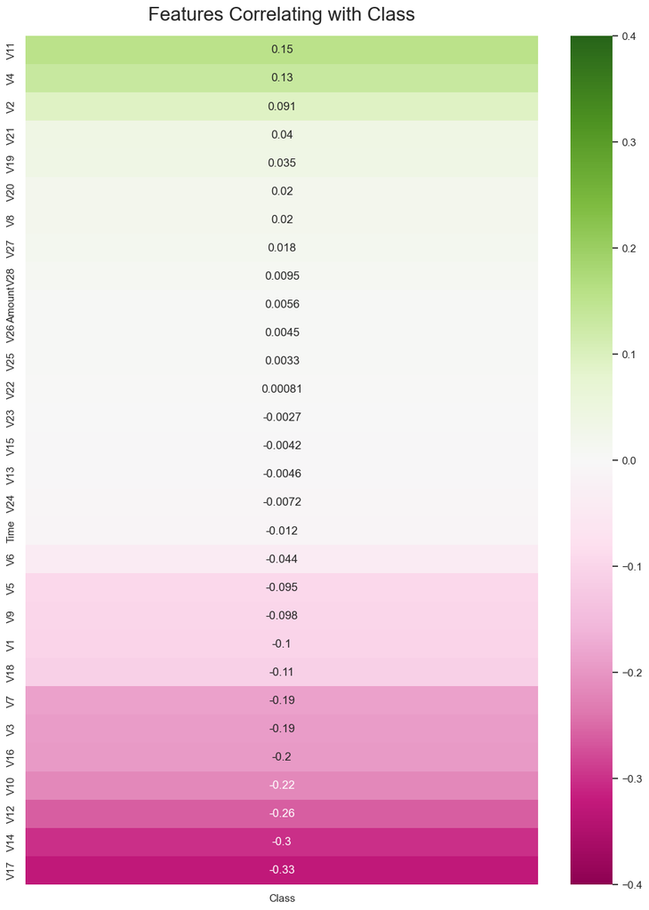

```python
plt.figure(figsize=(12, 16))
heatmap = sns.heatmap(data.corr()[['Class']].sort_values(by='Class', ascending=False).drop('Class'), vmin=-0.4, vmax=0.4, annot=True, cmap="PiYG")
heatmap.set_title('Features Correlating with Class', fontdict={'fontsize':20}, pad=16);
```

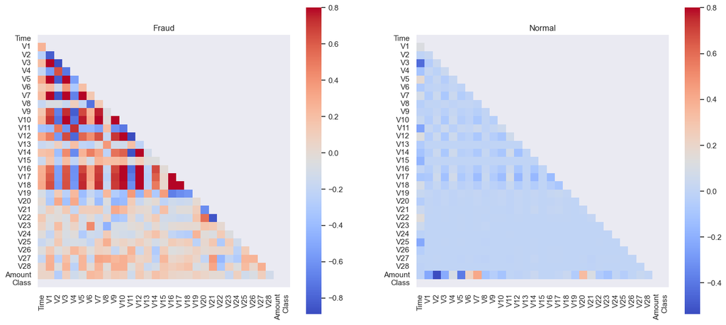

```python
# Correlation matrix
f, (ax1, ax2) = plt.subplots(1,2,figsize =( 18, 8))
corr = data.corr()
sns.heatmap((data.loc[data['Class'] ==1]).corr(), vmax = .8, square=True, ax = ax1, cmap = 'coolwarm', mask=mask);
ax1.set_title('Fraud')
sns.heatmap((data.loc[data['Class'] ==0]).corr(), vmax = .8, square=True, ax = ax2, cmap = 'coolwarm', mask=mask);
ax2.set_title('Normal')
plt.show()
```

## **Limpeza, Formatação e Separação dos dados**

Verificando dados nulos para cada coluna

```python
data.isnull().sum()
```

```
Time      0
V1        0
V2        0
V3        0
V4        0
V5        0
V6        0
V7        0
V8        0
V9        0
V10       0
V11       0
V12       0
V13       0
V14       0
V15       0
V16       0
V17       0
V18       0
V19       0
V20       0
V21       0
V22       0
V23       0
V24       0
V25       0
V26       0
V27       0
V28       0
Amount    0
Class     0
dtype: int64
```

```python
# Remove as linhas duplicadas se houver
data = data.drop_duplicates()
```

```python
data['Amount'] = StandardScaler().fit_transform(data['Amount'].values.reshape(-1, 1))
data = data.drop(['Time'], axis=1)
data.head()
```

|  | V1 | V2 | V3 | V4 | V5 | V6 | V7 | V8 | V9 | V10 | ... | V21 | V22 | V23 | V24 | V25 | V26 | V27 | V28 | Amount | Class |
| --- | --- | --- | --- | --- | --- | --- | --- | --- | --- | --- | --- | --- | --- | --- | --- | --- | --- | --- | --- | --- | --- |
| 0 | -1.36 | -0.07 | 2.54 | 1.38 | -0.34 | 0.46 | 0.24 | 0.10 | 0.36 | 0.09 | ... | -0.02 | 0.28 | -0.11 | 0.07 | 0.13 | -0.19 | 0.13 | -0.02 | 0.24 | 0 |
| 1 | 1.19 | 0.27 | 0.17 | 0.45 | 0.06 | -0.08 | -0.08 | 0.09 | -0.26 | -0.17 | ... | -0.23 | -0.64 | 0.10 | -0.34 | 0.17 | 0.13 | -0.01 | 0.01 | -0.34 | 0 |
| 2 | -1.36 | -1.34 | 1.77 | 0.38 | -0.50 | 1.80 | 0.79 | 0.25 | -1.51 | 0.21 | ... | 0.25 | 0.77 | 0.91 | -0.69 | -0.33 | -0.14 | -0.06 | -0.06 | 1.16 | 0 |
| 3 | -0.97 | -0.19 | 1.79 | -0.86 | -0.01 | 1.25 | 0.24 | 0.38 | -1.39 | -0.05 | ... | -0.11 | 0.01 | -0.19 | -1.18 | 0.65 | -0.22 | 0.06 | 0.06 | 0.14 | 0 |
| 4 | -1.16 | 0.88 | 1.55 | 0.40 | -0.41 | 0.10 | 0.59 | -0.27 | 0.82 | 0.75 | ... | -0.01 | 0.80 | -0.14 | 0.14 | -0.21 | 0.50 | 0.22 | 0.22 | -0.07 | 0 |

5 rows × 30 columns

```python
# Separando em X  e y
X = data.drop('Class', axis=1)
y = data.Class
```

**Separando o conjunto de treinamento e de teste**

Como estamos trabalhando com dados desbalanceados, para mantermos a mesma proporção entre as classes de treino e teste, utilizaremos o parâmetro **"stratify"**

```python
X_train, X_test, y_train, y_test = train_test_split(X, y,
                                                    test_size=0.2,
                                                    random_state=42,
                                                    stratify=y)
```

Ou seja, a proporção de fraudes e não-fraudes na base de treino está igual a proporção dos dados originais

```python
X_train_backup, X_test_backup, y_train_backup, y_test_backup = X_train.copy(), X_test.copy(), y_train.copy(), y_test.copy()
```

```python
print(f"Número de observações de cada classe para o conjunto de treino: \n{y_train.value_counts()}\n\n\n")
print(f"Número de observações de cada classe para o conjunto de teste: \n{y_test.value_counts()}")
```

```
Número de observações de cada classe para o conjunto de treino:
0    226602
1       378
Name: Class, dtype: int64



Número de observações de cada classe para o conjunto de teste:
0    56651
1       95
Name: Class, dtype: int64
```

```python
data.head()
```

|  | V1 | V2 | V3 | V4 | V5 | V6 | V7 | V8 | V9 | V10 | ... | V21 | V22 | V23 | V24 | V25 | V26 | V27 | V28 | Amount | Class |
| --- | --- | --- | --- | --- | --- | --- | --- | --- | --- | --- | --- | --- | --- | --- | --- | --- | --- | --- | --- | --- | --- |
| 0 | -1.36 | -0.07 | 2.54 | 1.38 | -0.34 | 0.46 | 0.24 | 0.10 | 0.36 | 0.09 | ... | -0.02 | 0.28 | -0.11 | 0.07 | 0.13 | -0.19 | 0.13 | -0.02 | 0.24 | 0 |
| 1 | 1.19 | 0.27 | 0.17 | 0.45 | 0.06 | -0.08 | -0.08 | 0.09 | -0.26 | -0.17 | ... | -0.23 | -0.64 | 0.10 | -0.34 | 0.17 | 0.13 | -0.01 | 0.01 | -0.34 | 0 |
| 2 | -1.36 | -1.34 | 1.77 | 0.38 | -0.50 | 1.80 | 0.79 | 0.25 | -1.51 | 0.21 | ... | 0.25 | 0.77 | 0.91 | -0.69 | -0.33 | -0.14 | -0.06 | -0.06 | 1.16 | 0 |
| 3 | -0.97 | -0.19 | 1.79 | -0.86 | -0.01 | 1.25 | 0.24 | 0.38 | -1.39 | -0.05 | ... | -0.11 | 0.01 | -0.19 | -1.18 | 0.65 | -0.22 | 0.06 | 0.06 | 0.14 | 0 |
| 4 | -1.16 | 0.88 | 1.55 | 0.40 | -0.41 | 0.10 | 0.59 | -0.27 | 0.82 | 0.75 | ... | -0.01 | 0.80 | -0.14 | 0.14 | -0.21 | 0.50 | 0.22 | 0.22 | -0.07 | 0 |

5 rows × 30 columns

## **Balanceando os dados de treino** *(RandomUnderSampler)*

Vamos equilibrar o número de registros em ambas as classes reduzindo os registros da classe majoritária.

É importante nos atentarmos na retirada de registros para que não cause perda de informação (retirar informações importantes). Além disso, é necessário verificar o tamanho da base restante.

**Sobre o método**

A subamostragem aleatória é uma técnica usada para equilibrar a distribuição de classes em um conjunto de dados. É comumente usado em tarefas de classificação desbalanceadas, onde uma classe é significativamente super-representada em comparação com a outra.

A ideia por trás da subamostragem aleatória é remover aleatoriamente pontos de dados da classe majoritária para equilibrar o conjunto de dados. Isso pode ser feito selecionando um subconjunto **aleatório** dos pontos de dados da classe majoritária e removendo-os do conjunto de dados. O tamanho do subconjunto deve ser escolhido de forma a equilibrar a distribuição de classes.

**Vantagens:**

- Simples e rápida;
- Eficaz para melhorar desempenho de modelos de machine learn em dados desbalanceados.

**Desvantagens:**

- Pode descartar informações valiosas e nem sempre pode ser a melhor escolha para lidar com conjuntos de dados desequilibrados.

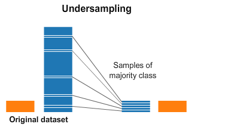

```python
# Definindo o RandomUnderSampler
rus = RandomUnderSampler(random_state=42)

X_resampled_RU, y_resampled_RU = rus.fit_resample(X_train, y_train) # X_resampled = X_train; y_resampled = y_train

rus_df = X_resampled_RU.copy()
rus_df['Class'] = y_resampled_RU.copy()

rus_df.iloc[:]
```

|  | V1 | V2 | V3 | V4 | V5 | V6 | V7 | V8 | V9 | V10 | ... | V21 | V22 | V23 | V24 | V25 | V26 | V27 | V28 | Amount | Class |
| --- | --- | --- | --- | --- | --- | --- | --- | --- | --- | --- | --- | --- | --- | --- | --- | --- | --- | --- | --- | --- | --- |
| 0 | 2.05 | 0.07 | -1.81 | 0.24 | 0.58 | -0.40 | 0.05 | -0.05 | 0.32 | -0.20 | ... | -0.34 | -0.92 | 0.30 | 0.17 | -0.26 | 0.17 | -0.07 | -0.04 | -0.35 | 0 |
| 1 | 1.94 | -1.23 | -0.44 | -0.70 | -1.32 | -0.84 | -0.77 | -0.20 | 0.00 | 0.65 | ... | 0.03 | -0.13 | 0.28 | 0.04 | -0.53 | -0.50 | -0.01 | -0.02 | 0.14 | 0 |
| 2 | -1.97 | 1.27 | 1.22 | 0.30 | -1.28 | 0.15 | -1.00 | 1.42 | -0.24 | -1.25 | ... | 0.19 | 0.30 | -0.06 | 0.16 | -0.29 | 0.27 | -0.46 | -0.13 | -0.24 | 0 |
| 3 | -1.22 | -0.00 | -0.14 | -1.31 | -0.36 | -2.02 | 0.24 | 0.08 | -1.33 | 0.55 | ... | -0.22 | -0.23 | 0.16 | 0.74 | -0.99 | 0.72 | 0.39 | 0.21 | -0.15 | 0 |
| 4 | 1.92 | -0.20 | -0.29 | 1.60 | -0.47 | -0.30 | -0.28 | 0.02 | 1.26 | -0.00 | ... | -0.52 | -1.23 | 0.45 | -0.11 | -0.35 | -1.10 | 0.05 | -0.03 | -0.30 | 0 |
| ... | ... | ... | ... | ... | ... | ... | ... | ... | ... | ... | ... | ... | ... | ... | ... | ... | ... | ... | ... | ... | ... |
| 751 | -0.72 | 0.61 | 1.16 | -0.27 | -0.56 | -0.62 | 0.70 | 0.07 | -0.13 | -1.03 | ... | 0.13 | 0.24 | -0.09 | 0.41 | -0.22 | 0.35 | -0.06 | 0.01 | 0.16 | 1 |
| 752 | -22.56 | 13.21 | -24.64 | 6.23 | -16.91 | -4.50 | -16.81 | 14.96 | -3.87 | -8.58 | ... | 1.77 | -1.64 | -1.00 | 0.14 | 1.56 | -0.22 | 1.50 | 0.45 | 0.05 | 1 |
| 753 | -1.37 | 2.79 | -4.35 | 2.40 | -1.69 | 0.11 | -0.92 | -2.15 | -2.03 | -4.39 | ... | -0.87 | 0.50 | 0.14 | 0.37 | 0.10 | -0.41 | 0.45 | 0.10 | 1.04 | 1 |
| 754 | -16.92 | 9.67 | -23.74 | 11.82 | -9.83 | -2.51 | -17.29 | 1.82 | -6.26 | -12.92 | ... | -2.34 | 0.97 | 1.24 | -1.05 | 0.04 | 0.67 | 2.11 | -1.42 | -0.35 | 1 |
| 755 | -1.40 | 2.62 | -6.04 | 3.55 | 1.03 | -2.95 | -1.53 | 0.19 | -1.43 | -5.57 | ... | 0.14 | -0.39 | 0.36 | -0.76 | 0.10 | -0.49 | 0.06 | -0.24 | -0.35 | 1 |

756 rows × 30 columns

```python
X_train, y_train = shuffle(X_resampled_RU, y_resampled_RU, random_state = 42) # shuffle our data
```

```python
print(f"Número de observações de cada classe para o conjunto de treino: \n{y_train.value_counts()}\n\n\n")
print(f"Número de observações de cada classe para o conjunto de teste: \n{y_test.value_counts()}")
```

```
Número de observações de cada classe para o conjunto de treino:
1    378
0    378
Name: Class, dtype: int64



Número de observações de cada classe para o conjunto de teste:
0    56651
1       95
Name: Class, dtype: int64
```

## **Montando modelos**

```python
reg = LazyClassifier(verbose=0,ignore_warnings=False, custom_metric=None )
models,predictions = reg.fit(X_train, X_test, y_train, y_test)
```

```
CategoricalNB model failed to execute
Negative values in data passed to CategoricalNB (input X)
```

```
StackingClassifier model failed to execute
__init__() missing 1 required positional argument: 'estimators'
```

```python
models
```

| Model | Accuracy | Balanced Accuracy | ROC AUC | F1 Score | Time Taken |
| --- | --- | --- | --- | --- | --- |
| RandomForestClassifier | 0.98 | 0.93 | 0.93 | 0.99 | 0.60 |
| LogisticRegression | 0.98 | 0.93 | 0.93 | 0.99 | 0.07 |
| LinearSVC | 0.97 | 0.92 | 0.92 | 0.99 | 0.09 |
| LGBMClassifier | 0.97 | 0.92 | 0.92 | 0.99 | 0.21 |
| DecisionTreeClassifier | 0.92 | 0.92 | 0.92 | 0.96 | 0.07 |
| XGBClassifier | 0.97 | 0.92 | 0.92 | 0.98 | 0.15 |
| SVC | 0.98 | 0.92 | 0.92 | 0.99 | 1.25 |
| ExtraTreesClassifier | 0.99 | 0.92 | 0.92 | 0.99 | 0.69 |
| AdaBoostClassifier | 0.96 | 0.92 | 0.92 | 0.98 | 0.58 |
| BaggingClassifier | 0.97 | 0.91 | 0.91 | 0.98 | 0.22 |
| SGDClassifier | 0.97 | 0.91 | 0.91 | 0.98 | 0.06 |
| CalibratedClassifierCV | 0.99 | 0.90 | 0.90 | 0.99 | 0.17 |
| QuadraticDiscriminantAnalysis | 0.94 | 0.89 | 0.89 | 0.97 | 0.11 |
| KNeighborsClassifier | 0.97 | 0.89 | 0.89 | 0.98 | 2.12 |
| RidgeClassifierCV | 0.99 | 0.89 | 0.89 | 0.99 | 0.07 |
| GaussianNB | 0.97 | 0.89 | 0.89 | 0.98 | 0.08 |
| RidgeClassifier | 0.99 | 0.89 | 0.89 | 0.99 | 0.08 |
| LinearDiscriminantAnalysis | 0.99 | 0.89 | 0.89 | 0.99 | 0.08 |
| BernoulliNB | 0.99 | 0.89 | 0.89 | 1.00 | 0.10 |
| NuSVC | 0.98 | 0.88 | 0.88 | 0.99 | 2.26 |
| LabelSpreading | 0.93 | 0.88 | 0.88 | 0.96 | 1.30 |
| LabelPropagation | 0.93 | 0.88 | 0.88 | 0.96 | 1.32 |
| ExtraTreeClassifier | 0.86 | 0.86 | 0.86 | 0.92 | 0.07 |
| NearestCentroid | 1.00 | 0.86 | 0.86 | 1.00 | 0.07 |
| Perceptron | 0.75 | 0.82 | 0.82 | 0.86 | 0.06 |
| PassiveAggressiveClassifier | 0.56 | 0.76 | 0.76 | 0.71 | 0.06 |
| DummyClassifier | 1.00 | 0.50 | 0.50 | 1.00 | 0.05 |

## **Seleção e avaliação de modelos**

Calcular a acurácia de dados desbalanceados pode não ser uma boa opção, por isso criaremos uma matriz de confusão para observarmos melhor os dados.

Para avaliarmos o modelo utilizaremos a seguintes métricas:

```
- É um equilíbrio entre precisão e recall e é útil quando você deseja pesar ambas as métricas igualmente. É uma boa métrica a ser usada quando você deseja evitar que a precisão ou o recall recebam muito peso. Por exemplo, se você estiver construindo um modelo para detectar transações fraudulentas e quiser evitar falsos positivos (sinalizar incorretamente uma transação legítima como fraudulenta) e falsos negativos (falha em sinalizar uma transação fraudulenta), F1 score pode ser útil métrica para otimizar.

- Varia de 0 a 1, com um valor mais alto indicando melhor desempenho. Uma pontuação perfeita é alcançada quando a precisão e a revocação são 1, ou seja, o modelo não tem falsos positivos ou falsos negativos
```

```
              precision    recall  f1-score   support

           0       1.00      0.97      0.99     56651
           1       0.05      0.87      0.10        95

    accuracy                           0.97     56746
   macro avg       0.53      0.92      0.54     56746
weighted avg       1.00      0.97      0.98     56746


accuracy_score:0.972614809854439
recall_score: 0.8736842105263158
precision_score: 0.051076923076923075
f1_score: 0.09651162790697675
```

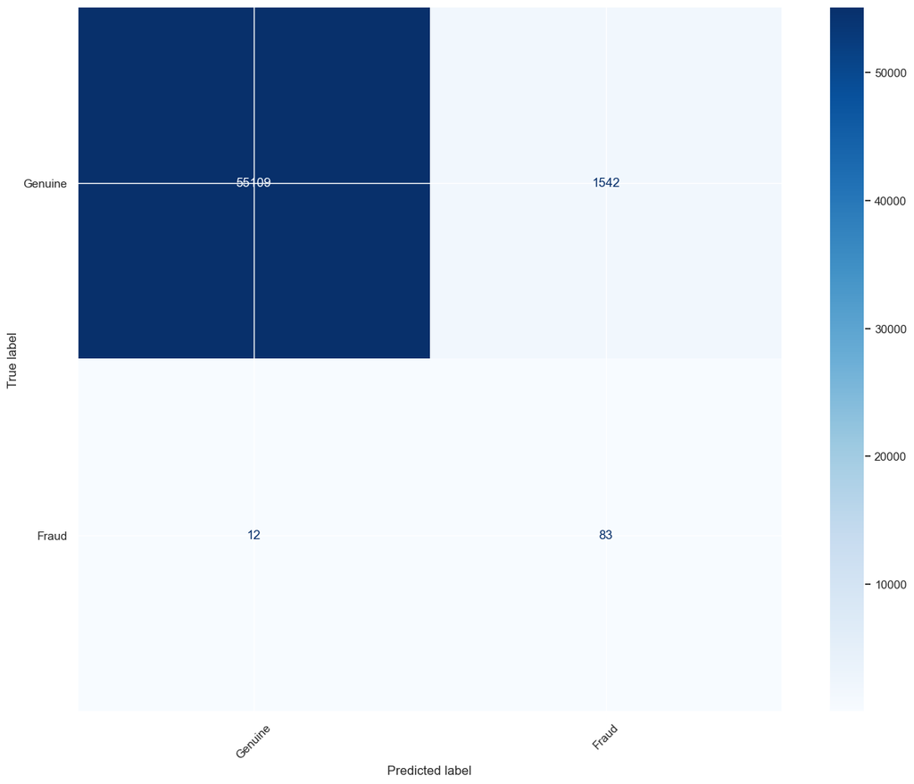

```python
LR = LogisticRegression(random_state=42).fit(X_train, y_train)
y_pred = LR.predict(X_test)

print(classification_report(y_test, y_pred))
print("")
print(f"accuracy_score:{accuracy_score(y_test, y_pred)}")
print(f"recall_score: {recall_score(y_test, y_pred)}")
print(f"precision_score: {precision_score(y_test, y_pred)}")
print(f"f1_score: {f1_score(y_test, y_pred)}")

confusion_matrix = metrics.confusion_matrix(y_test, y_pred)
cm_display = metrics.ConfusionMatrixDisplay(confusion_matrix = confusion_matrix, display_labels = ["Genuine", "Fraud"])
cm_display.plot(cmap=plt.cm.Blues, xticks_rotation=45);
```

Com esse modelo prevemos 83 fraudes de 95 em 56.746 observações do conjunto de teste, com:

- Falsos negativos: 12
- Falsos positivos: 1542

```
              precision    recall  f1-score   support

           0       1.00      0.98      0.99     56651
           1       0.08      0.87      0.15        95

    accuracy                           0.98     56746
   macro avg       0.54      0.93      0.57     56746
weighted avg       1.00      0.98      0.99     56746


accuracy_score:0.9834349557678074
recall_score: 0.8736842105263158
precision_score: 0.0820969337289812
f1_score: 0.15009041591320074
```

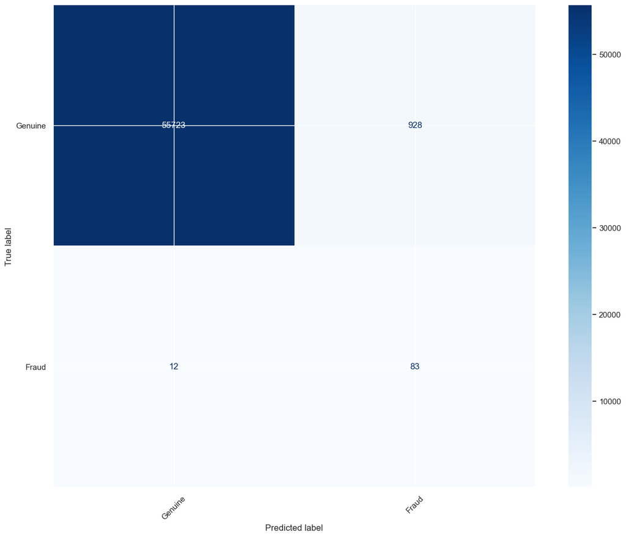

```python
RF = RandomForestClassifier(random_state=42).fit(X_train, y_train)
y_pred = RF.predict(X_test)

print(classification_report(y_test, y_pred))
print("")
print(f"accuracy_score:{accuracy_score(y_test, y_pred)}")
print(f"recall_score: {recall_score(y_test, y_pred)}")
print(f"precision_score: {precision_score(y_test, y_pred)}")
print(f"f1_score: {f1_score(y_test, y_pred)}")

confusion_matrix = metrics.confusion_matrix(y_test, y_pred)
cm_display = metrics.ConfusionMatrixDisplay(confusion_matrix = confusion_matrix, display_labels = ["Genuine", "Fraud"])
cm_display.plot(cmap=plt.cm.Blues, xticks_rotation=45);
```

Com esse modelo prevemos 83 fraudes de 95 em 56.746 observações do conjunto de teste, com:

- Falsos negativos: 12
- Falsos positivos: 928

## **Hyperparameters tuning**

Hiperparâmetros são parâmetros que não são aprendidos diretamente pelos modelos, sendo assim, é preciso atribuí-los antes do treinamento.

Os estimadores escolhidos para os hiperparâmetros não só influenciam na qualidade dos modelos, como também, na sua capacidade de aprendizado com o treinamento, e consequentemente na habilidade de generalização para dados não vistos anteriormente.

A técnica escolhida para ajuste de hiperparâmetros foi a ***Grid Search***, essa ferramenta considera exaustivamente todas as combinações de parâmetros possíveis.

```python
Model = LogisticRegression(random_state = 42)

param_grid = [
    {'penalty' : ['l1', 'l2', 'elasticnet', 'none'],
    'C' : np.logspace(-4, 4, 20),
    'solver' : ['lbfgs','newton-cg','liblinear','sag','saga'],
    'max_iter' : [100, 1000,2500, 5000]
    }
]
```

```python
clf = GridSearchCV(Model, param_grid = param_grid, cv = 3, verbose=True, n_jobs=-1, scoring = 'f1')
```

**JAMAIS RODAR ISSO NO COLAB**

```python
best_clf = clf.fit(X_train, y_train)
```

```
Fitting 3 folds for each of 1600 candidates, totalling 4800 fits
```

```python
print(f"Best estimator:\n\t{best_clf.best_estimator_}")
print(f"Tuned hyperparameters:\n\t{best_clf.best_params_}")
print(f"Best Accuracy:\n\t{best_clf.best_score_}")
```

```
Best estimator:
	LogisticRegression(C=0.08858667904100823, max_iter=1000, penalty='l1',
                   random_state=42, solver='saga')
Tuned hyperparameters:
	{'C': 0.08858667904100823, 'max_iter': 1000, 'penalty': 'l1', 'solver': 'saga'}
Best Accuracy:
	0.9362786954494194
```

```python
Model = RandomForestClassifier(random_state = 42)

param_grid = [
    {'n_estimators': [100, 50, 150],
    'criterion': ['gini', 'entropy']}
]
```

```python
clf = GridSearchCV(Model, param_grid = param_grid, cv = 5, verbose=True, n_jobs=-1, scoring = 'f1')
```

**JAMAIS RODAR ISSO NO COLAB**

```python
best_clf = clf.fit(X_train, y_train)
```

```
Fitting 5 folds for each of 6 candidates, totalling 30 fits
```

```python
print(f"Best estimator:\n\t{best_clf.best_estimator_}")
print(f"Tuned hyperparameters:\n\t{best_clf.best_params_}")
print(f"Best Accuracy:\n\t{best_clf.best_score_}")
```

```
Best estimator:
	RandomForestClassifier(random_state=42)
Tuned hyperparameters:
	{'criterion': 'gini', 'n_estimators': 100}
Best Accuracy:
	0.9352534767131561
```

```
              precision    recall  f1-score   support

           0       1.00      0.98      0.99     56651
           1       0.07      0.87      0.12        95

    accuracy                           0.98     56746
   macro avg       0.53      0.93      0.56     56746
weighted avg       1.00      0.98      0.99     56746


accuracy_score:0.979505163359532
recall_score: 0.8736842105263158
precision_score: 0.06726094003241491
f1_score: 0.12490594431903687
```

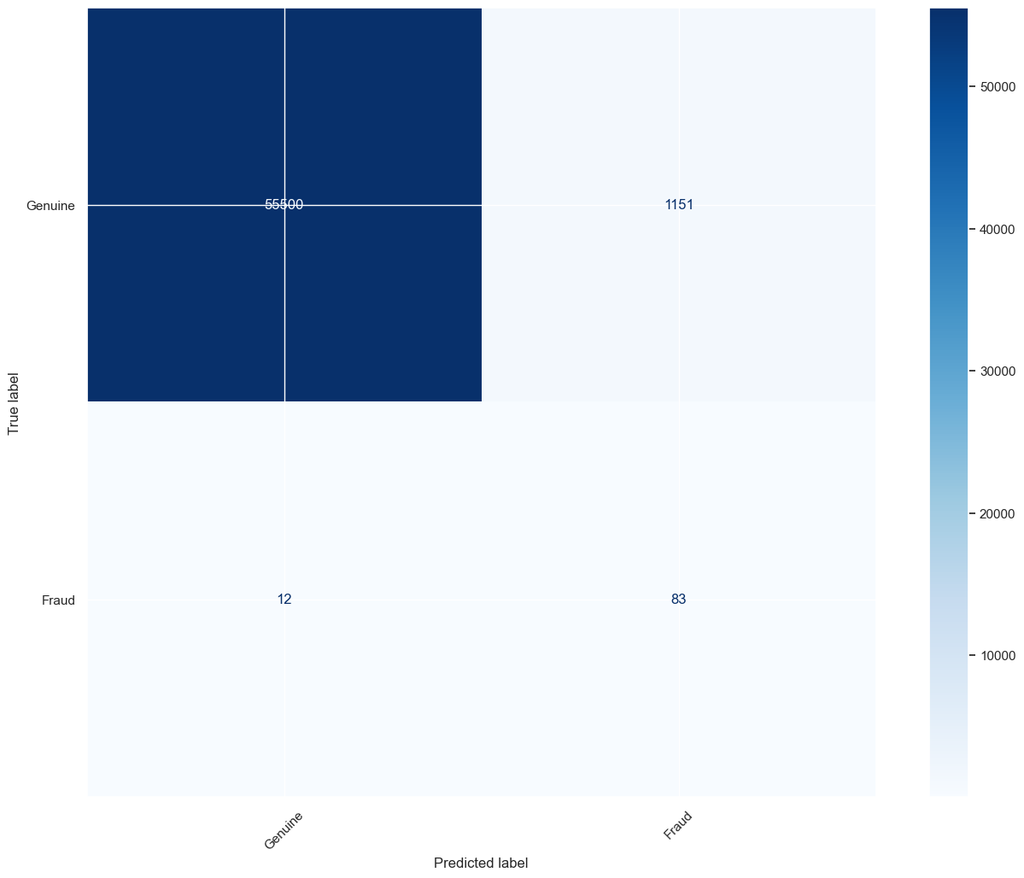

```python
model = LogisticRegression(C=0.08858667904100823,max_iter=100,penalty='l2',solver='lbfgs').fit(X_train, y_train)
y_pred = model.predict(X_test)

print(classification_report(y_test, y_pred))
print("")
print(f"accuracy_score:{accuracy_score(y_test, y_pred)}")
print(f"recall_score: {recall_score(y_test, y_pred)}")
print(f"precision_score: {precision_score(y_test, y_pred)}")
print(f"f1_score: {f1_score(y_test, y_pred)}")

models = [model]
cm_display = []
for i in models:
  confusion_matrix = metrics.confusion_matrix(y_test, i.predict(X_test))
  cm_display.append(metrics.ConfusionMatrixDisplay(confusion_matrix = confusion_matrix, display_labels = ["Genuine", "Fraud"]))

for i in cm_display:
  i.plot(cmap=plt.cm.Blues, xticks_rotation=45);
```

Com esse modelo prevemos 83 fraudes de 95 em 56.746 observações do conjunto de teste, com:

- Falsos negativos: 12
- Falsos positivos: 1151

## **Montando o modelo RF com os parametros encontrados**

```
              precision    recall  f1-score   support

           0       1.00      0.99      0.99     56651
           1       0.11      0.85      0.20        95

    accuracy                           0.99     56746
   macro avg       0.56      0.92      0.59     56746
weighted avg       1.00      0.99      0.99     56746


accuracy_score:0.9882634899376167
recall_score: 0.8526315789473684
precision_score: 0.11050477489768076
f1_score: 0.1956521739130435
```

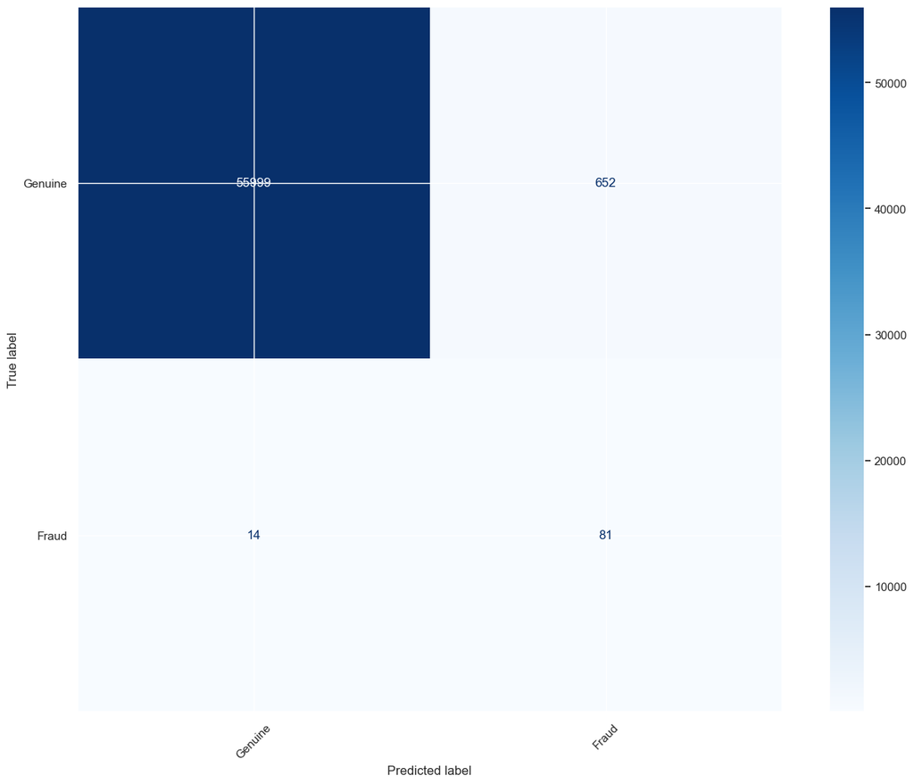

```python
model = RandomForestClassifier(criterion='entropy',n_estimators=50).fit(X_train, y_train)
y_pred = model.predict(X_test)

print(classification_report(y_test, y_pred))
print("")
print(f"accuracy_score:{accuracy_score(y_test, y_pred)}")
print(f"recall_score: {recall_score(y_test, y_pred)}")
print(f"precision_score: {precision_score(y_test, y_pred)}")
print(f"f1_score: {f1_score(y_test, y_pred)}")

confusion_matrix = metrics.confusion_matrix(y_test, y_pred)
cm_display = metrics.ConfusionMatrixDisplay(confusion_matrix = confusion_matrix, display_labels = ["Genuine", "Fraud"])
cm_display.plot(cmap=plt.cm.Blues, xticks_rotation=45);
```

```
              precision    recall  f1-score   support

           0       1.00      0.99      0.99     56651
           1       0.11      0.86      0.19        95

    accuracy                           0.99     56746
   macro avg       0.55      0.93      0.59     56746
weighted avg       1.00      0.99      0.99     56746


accuracy_score:0.9879639093504388
recall_score: 0.8631578947368421
precision_score: 0.10904255319148937
f1_score: 0.1936245572609209
```

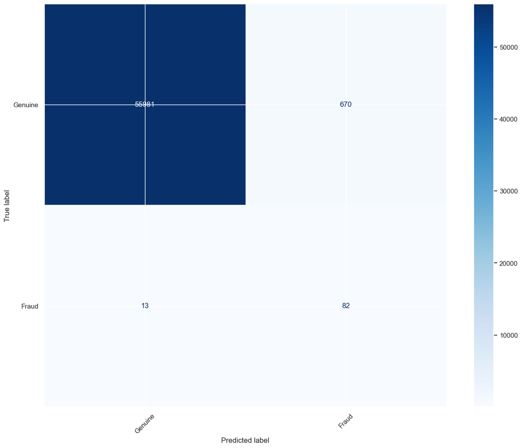

```python
model = RandomForestClassifier(criterion='entropy',max_depth=8,max_features='log2',n_estimators=50).fit(X_train, y_train)
y_pred = model.predict(X_test)

print(classification_report(y_test, y_pred))
print("")
print(f"accuracy_score:{accuracy_score(y_test, y_pred)}")
print(f"recall_score: {recall_score(y_test, y_pred)}")
print(f"precision_score: {precision_score(y_test, y_pred)}")
print(f"f1_score: {f1_score(y_test, y_pred)}")

confusion_matrix = metrics.confusion_matrix(y_test, y_pred)
cm_display = metrics.ConfusionMatrixDisplay(confusion_matrix = confusion_matrix, display_labels = ["Genuine", "Fraud"])
cm_display.plot(cmap=plt.cm.Blues, xticks_rotation=45);
```

## **Balanceando os dados de treino** *(SMOTE)*

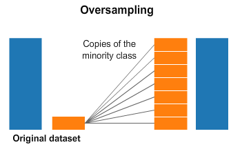

**SMOTE** (Synthetic Minority Over-sampling Technique) é uma técnica usada para equilibrar a distribuição de classes em um conjunto de dados. É comumente usado em tarefas de classificação desequilibradas, onde uma classe é significativamente sub-representada em comparação com a outra.

A ideia por trás do SMOTE é gerar pontos de dados sintéticos para a classe minoritária, a fim de equilibrar o conjunto de dados. Isso é feito selecionando um ponto de dados de classe minoritária e encontrando seus k vizinhos mais próximos. O algoritmo então cria um ponto de dados sintético interpolando entre o ponto de dados selecionado e um de seus vizinhos. Este processo é repetido até que o número desejado de pontos de dados sintéticos seja gerado.

O SMOTE demonstrou ser eficaz na melhoria do desempenho de modelos de aprendizado de máquina em conjuntos de dados desequilibrados. Isso pode ajudar a reduzir o viés em relação à classe majoritária e melhorar a capacidade do modelo de prever a classe minoritária. No entanto, é importante observar que o SMOTE também pode introduzir viés adicional e nem sempre ser a melhor escolha para lidar com conjuntos de dados desequilibrados. É sempre uma boa ideia tentar várias abordagens e comparar seu desempenho para determinar a melhor solução para um determinado problema.

```python
# Definindo o Random oversampling
sm = SMOTE(random_state=42)

X_resampled_SMOTE, y_resampled_SMOTE = sm.fit_resample(X_train_backup, y_train_backup) # X_resampled = X_train; y_resampled = y_train

sm_df = X_resampled_SMOTE.copy()
sm_df['Class'] = y_resampled_SMOTE.copy()

sm_df.iloc[:]
```

|  | V1 | V2 | V3 | V4 | V5 | V6 | V7 | V8 | V9 | V10 | ... | V21 | V22 | V23 | V24 | V25 | V26 | V27 | V28 | Amount | Class |
| --- | --- | --- | --- | --- | --- | --- | --- | --- | --- | --- | --- | --- | --- | --- | --- | --- | --- | --- | --- | --- | --- |
| 0 | 2.24 | -1.72 | -2.15 | -2.58 | 0.99 | 3.57 | -1.79 | 0.86 | -1.26 | 1.57 | ... | -0.15 | -0.05 | 0.28 | 0.68 | -0.22 | -0.16 | 0.04 | -0.05 | -0.23 | 0 |
| 1 | -1.32 | 1.63 | 0.60 | -0.04 | -0.40 | -0.97 | 0.21 | 0.74 | -1.27 | -0.48 | ... | -0.24 | -0.95 | 0.32 | 0.52 | -0.71 | -0.27 | -0.02 | 0.05 | -0.33 | 0 |
| 2 | 1.91 | 0.02 | -2.09 | 0.13 | 1.16 | 0.61 | -0.02 | 0.18 | 0.28 | -0.50 | ... | 0.29 | 1.10 | -0.04 | -1.69 | 0.11 | 0.01 | 0.05 | -0.05 | -0.29 | 0 |
| 3 | 1.81 | 0.32 | 0.32 | 3.88 | 0.05 | 1.02 | -0.73 | 0.23 | 0.68 | 1.15 | ... | 0.14 | 0.70 | 0.17 | 0.70 | -0.21 | -0.01 | -0.02 | -0.04 | -0.28 | 0 |
| 4 | 1.36 | -1.12 | 0.55 | -1.55 | -1.19 | 0.28 | -1.20 | 0.21 | -2.09 | 1.49 | ... | -0.34 | -0.64 | 0.25 | -0.34 | -0.06 | -0.44 | 0.06 | 0.01 | -0.26 | 0 |
| ... | ... | ... | ... | ... | ... | ... | ... | ... | ... | ... | ... | ... | ... | ... | ... | ... | ... | ... | ... | ... | ... |
| 453199 | -2.80 | 0.73 | -5.17 | 1.80 | -1.03 | -2.70 | -1.86 | 0.96 | -1.75 | -5.34 | ... | 0.63 | -0.28 | -0.17 | -0.21 | -0.10 | 0.65 | 0.73 | -0.15 | 0.78 | 1 |
| 453200 | -1.18 | 1.71 | -2.93 | 2.64 | 3.44 | -3.03 | -5.77 | -2.08 | -1.16 | -3.08 | ... | -0.71 | -0.30 | -5.69 | 0.68 | -1.52 | -0.59 | 0.81 | 0.48 | -0.35 | 1 |
| 453201 | 0.04 | 1.03 | -2.03 | 1.96 | -1.05 | -0.84 | -2.53 | 0.51 | -0.91 | -3.02 | ... | 0.58 | 0.49 | -0.13 | -0.51 | 0.59 | -0.25 | 0.58 | 0.16 | -0.32 | 1 |
| 453202 | 1.13 | 1.29 | -1.36 | 2.10 | 0.85 | -1.06 | 0.39 | -0.10 | -0.04 | -2.15 | ... | -0.36 | -0.69 | -0.12 | -0.13 | 0.67 | -0.32 | 0.11 | 0.13 | -0.35 | 1 |
| 453203 | -3.08 | 1.00 | -1.40 | 0.76 | -1.18 | -0.61 | -1.82 | 0.29 | -0.33 | -2.73 | ... | 0.47 | 0.51 | -0.22 | -0.34 | 0.10 | 0.43 | -1.10 | 0.42 | -0.06 | 1 |

453204 rows × 30 columns

```python
X_train, y_train = shuffle(X_resampled_SMOTE, y_resampled_SMOTE, random_state = 42) # shuffle our data
```

```python
print(f"Número de observações de cada classe para o conjunto de treino: \n{y_train.value_counts()}\n\n\n")
print(f"Número de observações de cada classe para o conjunto de teste: \n{y_test.value_counts()}")
```

```
Número de observações de cada classe para o conjunto de treino:
0    226602
1    226602
Name: Class, dtype: int64



Número de observações de cada classe para o conjunto de teste:
0    56651
1       95
Name: Class, dtype: int64
```

## **Montando modelos**

```
              precision    recall  f1-score   support

           0       1.00      0.97      0.99     56651
           1       0.05      0.87      0.10        95

    accuracy                           0.97     56746
   macro avg       0.53      0.92      0.54     56746
weighted avg       1.00      0.97      0.99     56746


accuracy_score:0.9739012441405561
recall_score: 0.8736842105263158
precision_score: 0.053479381443298966
f1_score: 0.100789313904068
```

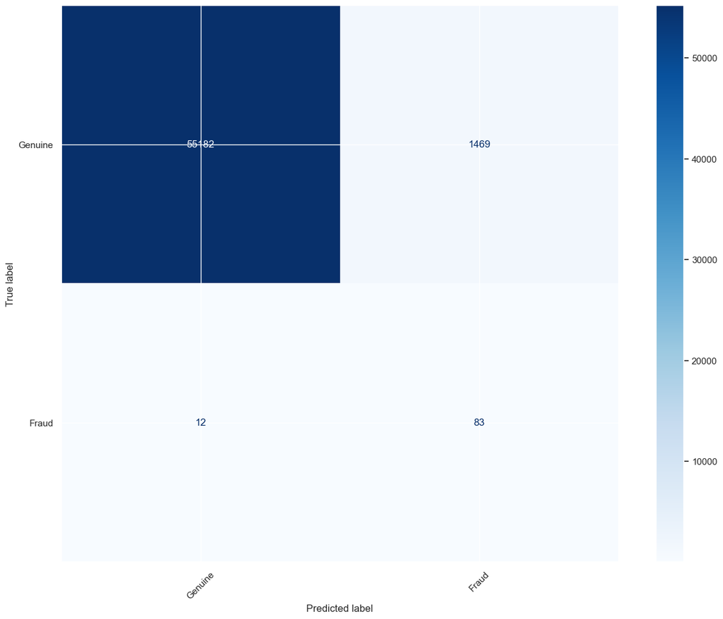

```python
LR = LogisticRegression(random_state=42).fit(X_train, y_train)
y_pred = LR.predict(X_test)

print(classification_report(y_test, y_pred))
print("")
print(f"accuracy_score:{accuracy_score(y_test, y_pred)}")
print(f"recall_score: {recall_score(y_test, y_pred)}")
print(f"precision_score: {precision_score(y_test, y_pred)}")
print(f"f1_score: {f1_score(y_test, y_pred)}")

confusion_matrix = metrics.confusion_matrix(y_test, y_pred)
cm_display = metrics.ConfusionMatrixDisplay(confusion_matrix = confusion_matrix, display_labels = ["Genuine", "Fraud"])
cm_display.plot(cmap=plt.cm.Blues, xticks_rotation=45);
```

Com esse modelo prevemos 83 fraudes de 95 em 56.746 observações do conjunto de teste, com:

- Falsos negativos: 12
- Falsos positivos: 1469

```
              precision    recall  f1-score   support

           0       1.00      1.00      1.00     56651
           1       0.94      0.77      0.84        95

    accuracy                           1.00     56746
   macro avg       0.97      0.88      0.92     56746
weighted avg       1.00      1.00      1.00     56746


accuracy_score:0.9995241955380115
recall_score: 0.7684210526315789
precision_score: 0.9358974358974359
f1_score: 0.8439306358381503
```

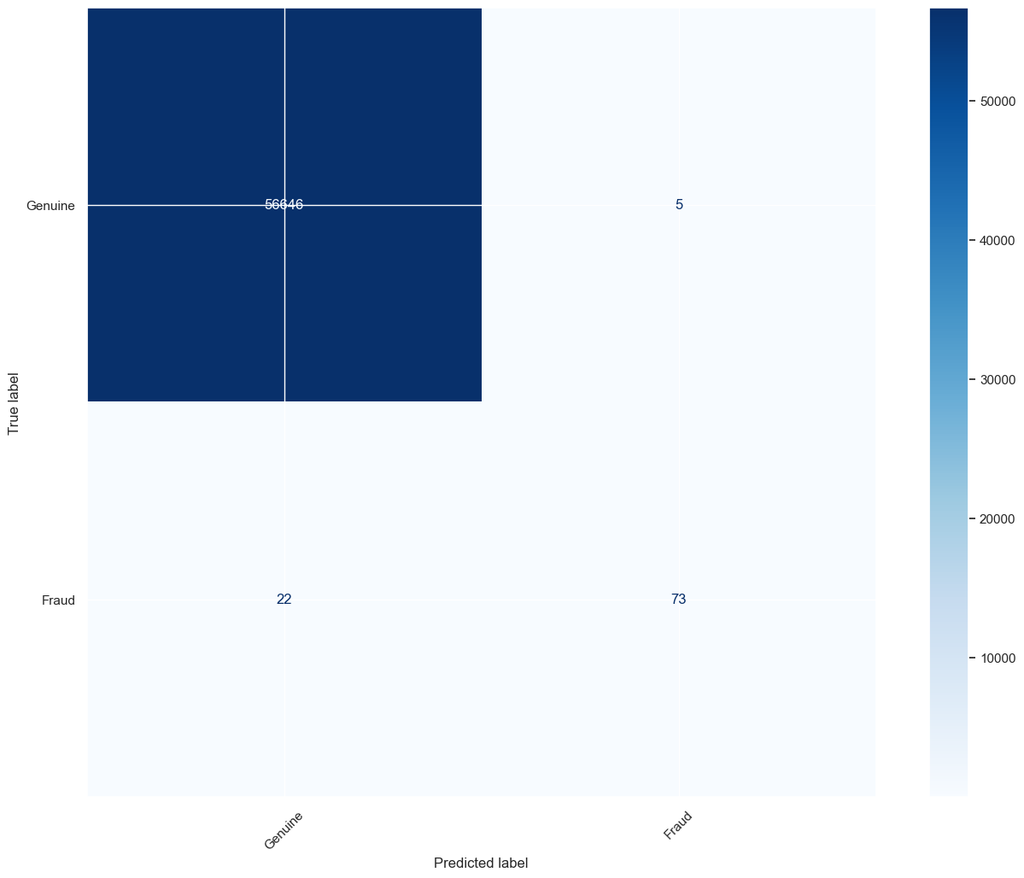

```python
RF = RandomForestClassifier(random_state=42).fit(X_train, y_train)
y_pred = RF.predict(X_test)

print(classification_report(y_test, y_pred))
print("")
print(f"accuracy_score:{accuracy_score(y_test, y_pred)}")
print(f"recall_score: {recall_score(y_test, y_pred)}")
print(f"precision_score: {precision_score(y_test, y_pred)}")
print(f"f1_score: {f1_score(y_test, y_pred)}")

confusion_matrix = metrics.confusion_matrix(y_test, y_pred)
cm_display = metrics.ConfusionMatrixDisplay(confusion_matrix = confusion_matrix, display_labels = ["Genuine", "Fraud"])
cm_display.plot(cmap=plt.cm.Blues, xticks_rotation=45);
```

Com esse modelo prevemos 73 fraudes de 95 em 56.746 observações do conjunto de teste, com:

- Falsos negativos: 22
- Falsos positivos: 5

## **Para o Modelo Random Forest** *(SMOTE)*

```python
importances = pd.DataFrame({'feature':X_train.columns,'importance':RF.feature_importances_})
importances = importances.sort_values('importance',ascending=False).reset_index(drop=True)
importances.iloc[:]
```

|  | feature | importance |
| --- | --- | --- |
| 0 | V10 | 0.16 |
| 1 | V14 | 0.14 |
| 2 | V4 | 0.11 |
| 3 | V12 | 0.11 |
| 4 | V11 | 0.09 |
| 5 | V17 | 0.07 |
| 6 | V16 | 0.05 |
| 7 | V7 | 0.05 |
| 8 | V3 | 0.03 |
| 9 | V2 | 0.02 |
| 10 | V21 | 0.01 |
| 11 | V8 | 0.01 |
| 12 | V18 | 0.01 |
| 13 | V5 | 0.01 |
| 14 | V9 | 0.01 |
| 15 | V19 | 0.01 |
| 16 | Amount | 0.01 |
| 17 | V27 | 0.01 |
| 18 | V1 | 0.01 |
| 19 | V13 | 0.01 |
| 20 | V26 | 0.01 |
| 21 | V15 | 0.01 |
| 22 | V28 | 0.01 |
| 23 | V20 | 0.01 |
| 24 | V25 | 0.01 |
| 25 | V6 | 0.00 |
| 26 | V23 | 0.00 |
| 27 | V22 | 0.00 |
| 28 | V24 | 0.00 |

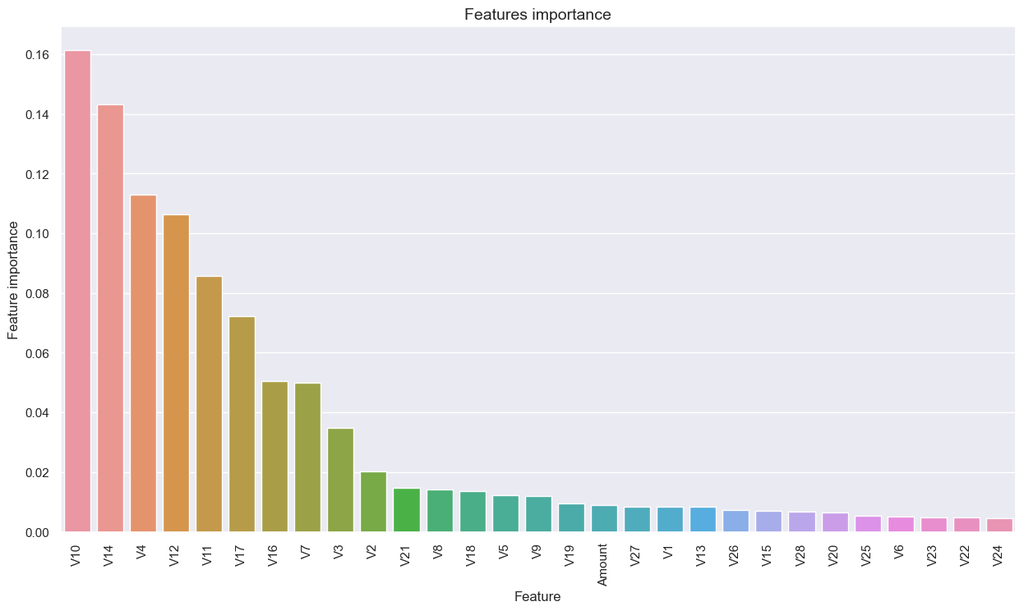

```python
tmp = pd.DataFrame({'Feature': X_train.columns, 'Feature importance': RF.feature_importances_})
tmp = tmp.sort_values(by='Feature importance',ascending=False)
plt.figure(figsize = (15,8))
plt.title('Features importance',fontsize=14)
s = sns.barplot(x='Feature',y='Feature importance',data=tmp)
s.set_xticklabels(s.get_xticklabels(),rotation=90)
plt.show()
```

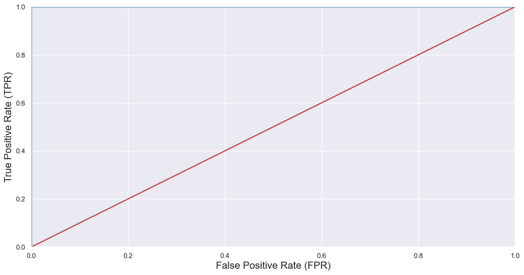

```python
y_scores = RF.predict_proba(X_train)
y_scores = y_scores[:,1]

false_positive_rate, true_positive_rate, thresholds = roc_curve(y_train, y_scores)
# plotting them against each other
def plot_roc_curve(false_positive_rate, true_positive_rate, label=None):
    plt.plot(false_positive_rate, true_positive_rate, linewidth=2, label=label)
    plt.plot([0, 1], [0, 1], 'r', linewidth=2)
    plt.axis([0, 1, 0, 1])
    plt.xlabel('False Positive Rate (FPR)', fontsize=16)
    plt.ylabel('True Positive Rate (TPR)', fontsize=16)

plt.figure(figsize=(14, 7))
plot_roc_curve(false_positive_rate, true_positive_rate)
plt.show()
```

```python
r_a_score = roc_auc_score(y_train, y_scores)
print("ROC-AUC-Score:", r_a_score)
```

```
ROC-AUC-Score: 1.0
```

## **Reduzindo o número de variáveis do modelo Random Forest** *(SMOTE)*

```python
print(importances.feature.to_list()[:18])
```

```
['V10', 'V14', 'V4', 'V12', 'V11', 'V17', 'V16', 'V7', 'V3', 'V2', 'V21', 'V8', 'V18', 'V5', 'V9', 'V19', 'Amount', 'V27']
```

```python
X_train_clean = X_train[importances.feature.to_list()[:18]]
X_train_clean.head()
```

|  | V10 | V14 | V4 | V12 | V11 | V17 | V16 | V7 | V3 | V2 | V21 | V8 | V18 | V5 | V9 | V19 | Amount | V27 |
| --- | --- | --- | --- | --- | --- | --- | --- | --- | --- | --- | --- | --- | --- | --- | --- | --- | --- | --- |
| 69368 | 0.32 | 0.62 | 0.69 | 0.83 | 1.16 | -0.26 | -0.58 | 0.85 | 0.12 | 1.09 | 0.19 | 0.02 | -0.02 | 0.79 | -0.82 | 0.44 | -0.35 | 0.46 |
| 333217 | -1.39 | -0.62 | -1.05 | 0.65 | -0.07 | -0.12 | -0.16 | 0.19 | 1.80 | 0.41 | 0.20 | 0.01 | 0.57 | -0.66 | 0.87 | 0.27 | -0.24 | 0.09 |
| 236756 | -13.34 | -11.10 | 10.48 | -14.82 | 6.20 | -18.34 | -9.84 | -15.15 | -18.32 | 7.54 | 2.52 | 8.61 | -7.44 | -12.04 | -5.89 | 1.00 | -0.03 | -2.43 |
| 444828 | -11.71 | -17.48 | 10.31 | -16.56 | 11.15 | -13.80 | -10.22 | -10.79 | -15.50 | 8.64 | 1.99 | 5.06 | -5.01 | -4.35 | -5.69 | 1.16 | -0.35 | 1.61 |
| 202589 | -0.46 | 1.13 | -0.79 | 0.59 | -0.49 | -0.81 | 0.32 | 0.17 | -1.46 | 1.42 | 0.45 | 0.82 | 1.10 | 0.75 | -0.49 | 0.74 | -0.35 | 0.12 |

```python
X_test_clean = X_test[importances.feature.to_list()[:18]]
X_test_clean.head()
```

|  | V10 | V14 | V4 | V12 | V11 | V17 | V16 | V7 | V3 | V2 | V21 | V8 | V18 | V5 | V9 | V19 | Amount | V27 |
| --- | --- | --- | --- | --- | --- | --- | --- | --- | --- | --- | --- | --- | --- | --- | --- | --- | --- | --- |
| 86568 | -0.27 | -0.29 | 0.65 | 0.47 | -1.25 | 0.03 | -0.40 | -0.22 | 0.27 | -0.06 | -0.13 | 0.08 | -0.78 | -0.05 | 0.64 | 0.14 | -0.31 | 0.00 |
| 251557 | -0.51 | 0.73 | -0.52 | -0.09 | -1.39 | -0.43 | -0.20 | 0.64 | -0.76 | 1.18 | 0.38 | 0.24 | 0.35 | 0.63 | -0.16 | 0.16 | -0.35 | 0.38 |
| 20232 | 3.07 | -0.95 | 2.18 | 0.20 | 0.77 | -1.22 | 0.37 | 1.11 | 1.50 | 1.40 | -0.53 | -0.54 | 0.60 | 0.70 | -0.25 | 1.43 | 0.01 | 0.01 |
| 68952 | 0.87 | 0.28 | 0.51 | 0.39 | 0.91 | -0.43 | -1.00 | -0.58 | 0.52 | -1.12 | -0.06 | 0.19 | 1.77 | -1.01 | -1.00 | -1.40 | 0.56 | 0.04 |
| 191852 | -0.53 | -1.64 | 0.59 | 1.04 | 0.99 | 0.89 | 0.32 | 0.01 | -1.75 | 0.11 | 0.01 | -0.13 | 0.61 | 0.37 | 0.49 | 0.22 | -0.35 | -0.04 |

```
              precision    recall  f1-score   support

           0       1.00      1.00      1.00     56651
           1       0.89      0.77      0.82        95

    accuracy                           1.00     56746
   macro avg       0.94      0.88      0.91     56746
weighted avg       1.00      1.00      1.00     56746


accuracy_score:0.9994537059880872
recall_score: 0.7684210526315789
precision_score: 0.8902439024390244
f1_score: 0.8248587570621468
```

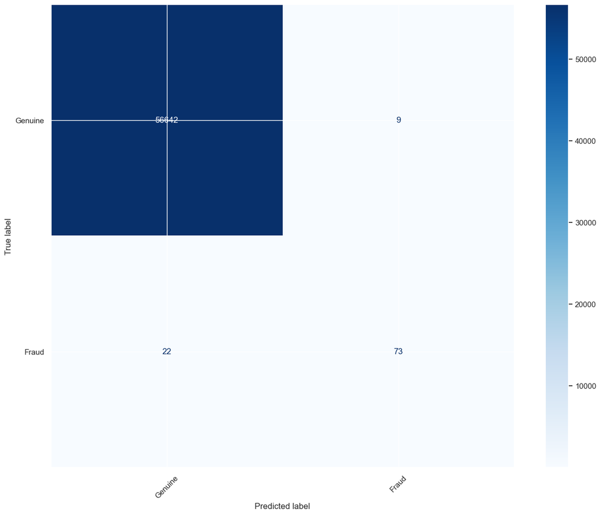

```python
RF = RandomForestClassifier(random_state=42).fit(X_train_clean, y_train)
y_pred = RF.predict(X_test_clean)

print(classification_report(y_test, y_pred))
print("")
print(f"accuracy_score:{accuracy_score(y_test, y_pred)}")
print(f"recall_score: {recall_score(y_test, y_pred)}")
print(f"precision_score: {precision_score(y_test, y_pred)}")
print(f"f1_score: {f1_score(y_test, y_pred)}")

confusion_matrix = metrics.confusion_matrix(y_test, y_pred)
cm_display = metrics.ConfusionMatrixDisplay(confusion_matrix = confusion_matrix, display_labels = ["Genuine", "Fraud"])
cm_display.plot(cmap=plt.cm.Blues, xticks_rotation=45);
```

Caclulando a acurária por cross validação

```python
scores = cross_validate(RF, X_train_clean, y_train, cv=5, scoring = "accuracy")
print(f"Scores: {scores['test_score']}\n")
crossval = pd.DataFrame({'statistics': ['mean', 'standard deviation'], 'value': [scores['test_score'].mean(), scores['test_score'].std()]})
crossval.iloc[:]
```

```
Scores: [0.99982348 0.99992277 0.99985658 0.99979038 0.99988967]
```

|  | statistics | value |
| --- | --- | --- |
| 0 | mean | 1.00 |
| 1 | standard deviation | 0.00 |

Com esse modelo prevemos 73 fraudes de 95 em 56.746 observações do conjunto de teste, com:

- Falsos negativos: 22
- Falsos positivos: 9

```python
importances = pd.DataFrame({'feature':X_train_clean.columns,'importance':RF.feature_importances_})
importances = importances.sort_values('importance',ascending=False).reset_index(drop=True)
importances.iloc[:]
```

|  | feature | importance |
| --- | --- | --- |
| 0 | V14 | 0.22 |
| 1 | V10 | 0.14 |
| 2 | V12 | 0.12 |
| 3 | V17 | 0.12 |
| 4 | V4 | 0.12 |
| 5 | V11 | 0.06 |
| 6 | V16 | 0.05 |
| 7 | V3 | 0.03 |
| 8 | V8 | 0.02 |
| 9 | V7 | 0.02 |
| 10 | V2 | 0.02 |
| 11 | V18 | 0.01 |
| 12 | V5 | 0.01 |
| 13 | V19 | 0.01 |
| 14 | Amount | 0.01 |
| 15 | V9 | 0.01 |
| 16 | V21 | 0.01 |
| 17 | V27 | 0.01 |

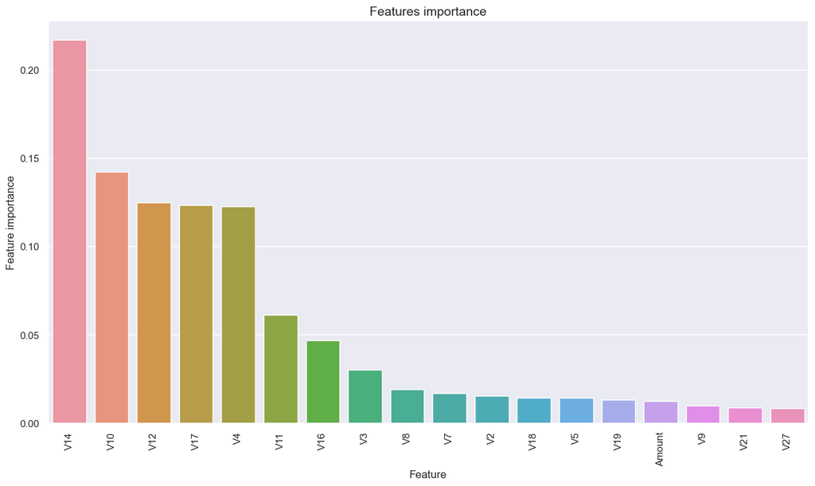

```python
tmp = pd.DataFrame({'Feature': X_train_clean.columns, 'Feature importance': RF.feature_importances_})
tmp = tmp.sort_values(by='Feature importance',ascending=False)
plt.figure(figsize = (15,8))
plt.title('Features importance',fontsize=14)
s = sns.barplot(x='Feature',y='Feature importance',data=tmp)
s.set_xticklabels(s.get_xticklabels(),rotation=90)
plt.show()
```

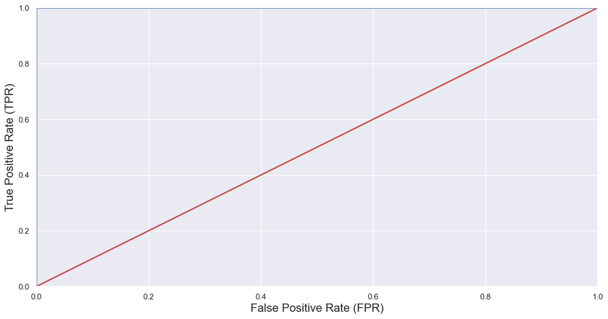

```python
y_scores = RF.predict_proba(X_train_clean)
y_scores = y_scores[:,1]

false_positive_rate, true_positive_rate, thresholds = roc_curve(y_train, y_scores)
# plotting them against each other
def plot_roc_curve(false_positive_rate, true_positive_rate, label=None):
    plt.plot(false_positive_rate, true_positive_rate, linewidth=2, label=label)
    plt.plot([0, 1], [0, 1], 'r', linewidth=2)
    plt.axis([0, 1, 0, 1])
    plt.xlabel('False Positive Rate (FPR)', fontsize=16)
    plt.ylabel('True Positive Rate (TPR)', fontsize=16)

plt.figure(figsize=(14, 7))
plot_roc_curve(false_positive_rate, true_positive_rate)
plt.show()
```

```python
r_a_score = roc_auc_score(y_train, y_scores)
print("ROC-AUC-Score:", r_a_score)
```

```
ROC-AUC-Score: 1.0
```

O modelo selecionado para prever fraudes em transações foi o ultimo modelo, o qual representa um classificador Random Forest, em que os dados de treino foram balanceados pelo metodo SMOTE sendo a variável Amount padronizada e Time não foi incluido nesses dados, os dados de teste são similares, porém não foram balanceados.

Com o modelo final obtivemos para o conjunto de teste(56.746 observações):

- 73 de 95 fraudes preditas
- Falsos negativos: 22
- Falsos positivos: 9
- Recall: 0.7684210526315789
- Precisão: 0.8902439024390244
- F1: 0.8248587570621468

## **Conclusão**

No final chegamos em um bom classificador devido a sua grande precisão em predizer transações fraudulentas. Também temos um pequeno número de falsos positivos, indicando que o modelo não irá ficar indicando transações genuínas como fraude.

Além disso, o classificador se apresentou capaz de lidar com dados desbalanceados, onde o número de casos não fraudulentos supera em muito o número de casos fraudulentos.

Após aplicarmos o ajuste de hiperparâmetros nos modelos de Regressão Logística e Random Forest, observamos uma melhora nas métricas de avaliação, como por exemplo, f1 score, precision, recall e accuracy.

O método SMOTE melhorou significativamente as métricas de avaliação do modelo de Random Forest, com acurácia igual a 1

Um proximo passo para melhor a eficacia na predição seria melhorar os hiperparametros do modelo(grande custo computacional) ou optar por modelos mais recentes que possuem um menor custo computacional mantendo sua boa eficacia como o modelo LightGBM.

## **Referências**

- https://www.kaggle.com/code/qianchao/smote-with-imbalance-data
- https://datascience.stackexchange.com/questions/61858/oversampling-undersampling-only-train-set-only-or-both-train-and-validation-set
- https://www.kaggle.com/code/janiobachmann/credit-fraud-dealing-with-imbalanced-datasets